# Class 12: Responses to Political Violence

State responses: repression

[Dr. Michael C. Zeller](https://michaelzeller.de)

# Opening notes

[Open Sticker](https://tenor.com/view/open-gif-14209777)from [Open Stickers](https://tenor.com/search/open-stickers)

- **short synopsis** for final essay due **Friday (17 January)** (send to me via email)

## Course feedback

Please take a few minutes to fill in the course feedback survey (check your LMU email).

If have an opinion on these points in the comments:

- Would you have preferred getting a specific assigned organisation to independently study in depth? Yes/No
- Would you have liked more structured discussions (e.g., set debates on class topics)? Yes/No
- Would you rather that class readings are drawn from textbook(s) than journal articles? Yes/No
- changes or additions to the course website?

# State repressive responses

- What options/possibilities are there
- dimensions of repression/social control
- al-Anani (2019) - Rethinking the repression-dissent nexus
- a repressive measure recently in the news

[Help Repressed GIF](https://tenor.com/view/help-repressed-panic-dance-medieval-gif-16574758)from [Help GIFs](https://tenor.com/search/help-gifs)

## Starting question

**What repressive measures can be applied to address (potential) political violence? In democratic systems? In authoritarian systems?**

## 3 dimensions of repression/social control (Earl 2003)

| Identity of repressive agent | State agents tightly connected with national political elites (e.g., military units) | State agents loosely connected with national political elites (e.g., local police departments) | Private agents (e.g., counter-demonstrators) |
| --- | --- | --- | --- |
| Character of repressive action | Coercion (e.g., use of tear gas and rubber bullets) | Channelling (e.g., restrictions on registered organisations) |  |
| Whether repressive action is observable | Observable (i.e., overt; e.g., Tiananmen Square) | Unobserved (i.e., covert or latent; e.g., COINTELPRO) |  |

What sort of repression/social control in cases do you know of? Was it effective? Why/How?

## al-Anani (2019) - responses to repression

- collective responses to repression
  - opposition movements’ tactics in responding to repression (i.e. mobilisation, backlash, de-escalation, etc.)
- individual responses to repression
  - specific individuals’ reactions to repression, shaped by emotions, memory, personal experiences, and grievances (e.g., disengagement, radicalisation)

## al-Anani (2019) - research in brief

- 20 interviews between 2016 and 2018 with current and former members of Muslim Brotherhood
  - any notes about Egyptian context or specifics of Muslim Brotherhood?
- repression has differential (individual-specific) effect

> Emotions such as **anger**, **hate**, and **despair** have played a key role in shaping their response to repression. Members had different responses that ranged from adopting revolutionary and confrontational tactics to political apathy. [p. 8]

## al-Anani (2019) - research in brief

- 20 interviews between 2016 and 2018 with current and former members of Muslim Brotherhood
  - any notes about Egyptian context or specifics of Muslim Brotherhood?
- conjunctural cause of **disengagement**

> The **high cost of protesting** and political participation **coupled with frustration** from the Brotherhood’s **incapable leadership** disenchanted several members who not only **broke ties** with the Brotherhood but also with politics as a whole.

## Discussion point: pressure against Höcke

- GG [Article 18](https://www.gesetze-im-internet.de/englisch_gg/englisch_gg.html#p0100) enables the BVerfG to **suspend an individual’s fundamental rights** (i.e., free expression, freedom of the press, and the right to vote and hold public office)
- the federal government has filed against 4 people in history of BRD
  - 1. [Otto Ernst Remer](https://www.kas.de/de/web/extremismus/rechtsextremismus/falsche-vorbilder-otto-ernst-remer) in 1960; 2. [Gerhard Frey](https://www.zeit.de/politik/deutschland/2013-02/dvu-frey) in 1974; 3. [Heinz Reisz](https://taz.de/Dienel-und-Reisz-Zwei-Einpeitscher-der-Rechten/!1639813/) in 1992; 4. [Thomas Dienel](https://taz.de/Dienel-und-Reisz-Zwei-Einpeitscher-der-Rechten/!1639813/) in 1992
  - **all rejected by BVerfG**
- calls to file against Björn Höcke (AfD Thüringen) (e.g., DPA 2024)
  - 2019: Verwaltungsgericht Meiningen rules that *he may be described as ‘fascist’* ([link](https://www.zeit.de/politik/deutschland/2019-09/afd-bjoern-hoecke-faschist-verwaltungsgericht-meinigen)); 2023: Hamburger Staatsanwaltschaft, it is not a legal offence (*Beleidigung*) to call Höcke a ‘Nazi’ ([link](https://www.fr.de/politik/afd-bjoern-hoecke-staatsanwaltschaft-faschist-nazi-hamburg-frankfurt-zr-92664548.html))

should the government file the complaint? should it be granted?

# Poll: Repressive measures

[figure not shown]

Take the survey at **https://forms.gle/C3mgptnc3oX4hYd57**

- Repression reduces (non-state) violence?
- Repression more likely to *deter* than to *radicalise* bystanders?
- Strategy most likely to end political violence?
- Why do you think states ban groups?

Questions about groups: (1) The state infiltrated or monitored the group? (2) Repression is a central to the state’s strategy? (3) Repression against group viewed as legitimate? (4) Repression reduced group’s operational capacity? (5) State cooperates internationally against group?

[interactive chart not shown]

Repression reduces non-state political violence?

[interactive chart not shown]

Repression more likely to *deter* than to *radicalise* bystanders?

[interactive chart not shown]

## Poll results - ending violence

Strategy most likely to end political violence?

[interactive chart not shown]

## Poll results - banning groups

Why do you think states ban groups?

[interactive chart not shown]

## Groups and repression

The state infiltrated or monitored the group.

[interactive chart not shown]

Repression is a central to the state’s strategy

[interactive chart not shown]

## Groups and repression

Repression viewed as legitimate

[interactive chart not shown]

## Groups and repression

Repression reduced group’s operational capacity

[interactive chart not shown]

State cooperates internationally against group

[interactive chart not shown]

# Banning

- banning - the most severe legal instrument states have
  - (legal) causes
  - consequences
- party bans (Bourne and Veugelers 2022)
- organisation banning patterns in Germany (Zeller 2025)

[Banned Comic Book Guy GIF](https://tenor.com/view/banned-comic-book-guy-simpsons-gif-17311572905376056687)from [Banned GIFs](https://tenor.com/search/banned-gifs)

## banning

- (legal) justifications (in Germany, but similar in several other countries) (Arts. 21(2), 9(2) GG; *Vereinsgesetz*)
  - seeks to undermine or abolish the free democratic basic order
  - opposition to core constitutional principles (human dignity [(Art. 1 GG)], democracy, rule of law)
  - directed against ‘international understanding’
  - in continual violation of criminal law
- consequences
  - further activity is criminalised
  - re-forming the organisation is criminalised
  - assets are confiscated

## Comparative case selection

x = causal variable; y = phenomenon to be explained

MDSD (most different systems design)

| Case 1 | Case 2 | _ |
| --- | --- | --- |
| a | d | overall |
| b | e | differences |
| c | f |  |
| x | x | crucial |
| y | y | similarity |

MSSD (most similar systems design)

| Case 1 | Case 2 | _ |
| --- | --- | --- |
| a | a | overall |
| b | b | similiarities |
| c | c |  |
| x | not x | crucial |
| y | not y | difference |

Further on case selection strategies, see Gerring (2007, e.g., pp. 89-90)

## Banning successor parties - Bourne and Veugelers (2022)

- case selection: DE and IT: similar right-authoritarian past [and banning law] but dissimilar in their tolerance of post-1945 right-authoritarian parties
  - MSSD (sort of)
- population: militant democracies - what does this mean?
- observations: (1) attitude towards violence, (2) alternatives to ban, (3) securitisation, (4) veto player agreement, (5) veto player incentives
- method: csQCA (Well, more a ‘focused paired comparison’)

Otto Ernst Remer, SRP

[figure not shown]

[figure not shown]

*Movimento sociale italiano*

## Banning successor parties - Bourne and Veugelers (2022)

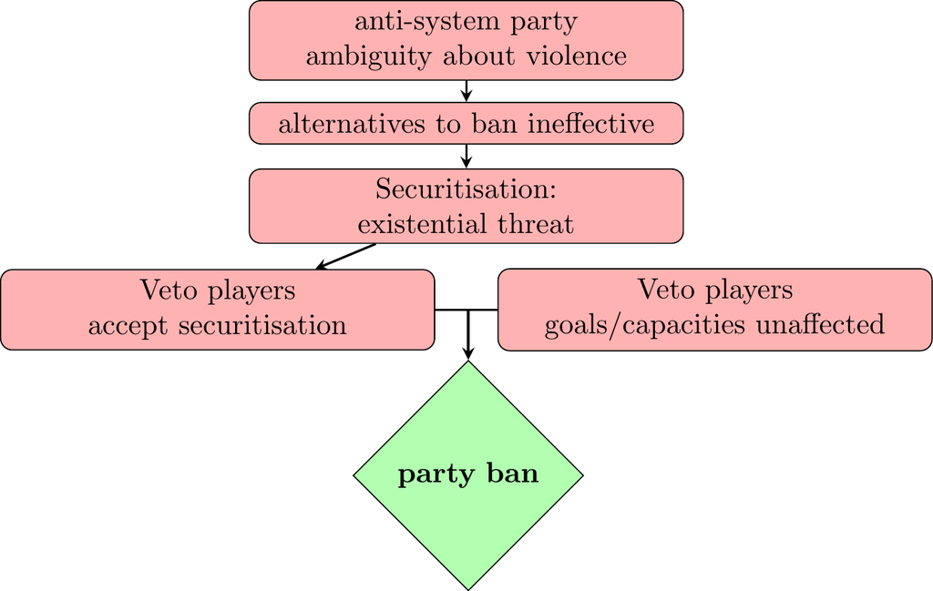

## Banning successor parties - Bourne and Veugelers (2022)

- (slightly permeable) cordon sanitaire around MSI (ban alternative)

findings:

- attitude towards violence *not* a clearly important factor
- two key conditions: veto player agreement and (especially) securitization

Any modern examples worth comparing to…?

## Banned & monitored (nationally) FR orgs in Germany (Zeller 2025)

- Organisations monitored by Bundesverfassungsschutz (VfS)
  - o: monitored by VfS, but not banned
  - x: banned by BRD interior ministry

## Banned & monitored (nationally) FR orgs in Germany (Zeller 2025)

- Organisations monitored by Bundesverfassungsschutz (VfS)
  - o: monitored by VfS, but not banned
  - x: banned by BRD interior ministry
- many groups/orgs. exist that are in violation of the law; they are monitored; but they are not banned. Why?

## Banned & monitored (nationally) FR orgs in Germany (Zeller 2025)

- Organisations monitored by Bundesverfassungsschutz (VfS)
  - o: monitored by VfS, but not banned
  - x: banned by BRD interior ministry
- many groups/orgs. exist that are in violation of the law; they are monitored; but they are not banned.
- a mixture of situational (*and contextual, but that’s for cross-country comparison*) and proximate conditions that lead to bans

## Monitored (nationally) FR orgs in Germany (Zeller 2025)

[interactive chart not shown]

## Banning FR orgs in Germany - necessity (Zeller 2025)

- high far-right visibility is necessary for banning decisions

> German governments banned far-right organisations only in years when far-right activity, in the form of violence or agitation, was highly visible. Conspicuous incidents of violence in particular were often a prod to proscriptive action. Organisational unlawfulness alone is not enough to explain banning decisions. Without public or political awareness, authorities appear unlikely to act, even if a group is technically illegal.

## Banning FR orgs in Germany - sufficient patterns (Zeller 2025)

1. Neo-Nazi movement groups – organisations promote National Socialist ideology—legally sufficient for banning in Germany and several other countries—as well as racial hatred and violence.
2. Longstanding hubs – long existing organisations, serving as centres of far-right activism and networking (network disruption strategy in banning decisions?)
3. Militant organisations – organisations embody particularly aggressive, confrontational far-right activism
4. Neo-Nazi sham parties – organisations presented as parties (hoping for status’s protection) but still spread neo-Nazi ideology

## Case 1: Nationale Offensive (NO) (Zeller 2025)

- typical of neo-Nazi sham parties pattern
- founded 1990 (by split from FAP) → linked to previously banned group
- not serious electoral contestation:
  - 0.2 per cent at local elections in Singen-Konstanz
  - 1992 BW Landtag elections: 183 votes out of five million cast
- **BAN**: by Rudolf Seiters (CDU): the NO ‘created and fuelled a xenophobic mood.’
- NO *appealed…* → Federal Administrative Court *quashed* appeal

**mechanism**: *social and political pressure* on minister ← indignation about high levels of far-right violence (HVIO) situation

## Case 2: Collegium Humanum (CH) (Zeller 2025)

- typical of longstanding hubs pattern
- founded 1963 by Haverbeck (d. 1999) and Haverbeck-Wetzel
  - **had charitable status** (*Gemeinnützigkeit*)
  - meeting point (Vlotho, NRW) for far-right activists from all over
    - *are there any banned orgs. to which the CH was not linked?!*
  - publication: *Stimme des Gewissens*
- **BAN**: by Wolfgang Schäuble (CDU): the CH was directed against Germany’s constitutional order and repeatedly violated laws against Holocaust denial

## Case 2: Collegium Humanum (CH) (Zeller 2025)

- typical of longstanding hubs pattern
- CH *appealed…* – Federal Administrative Court *denied* appeal
  1. CH publications repeatedly denied the Holocaust
  2. CH publications showed an affinity to and attempt to promote National Socialism
  - **ideology of CH publication was sufficient legal basis** (cf. Bundesverfassungsgericht 2009) – many fit this qualification…
- Mendel-Grundmann-Gesellschaft (MGG) active in Vlotho (research, then outreach)
- *Vlothoer Bündnis gegen das CH* (by local Greens)
- **mechanism**: high *specific* visibility, driven by local counter-mobilisation

## informative epilogue to these cases (Zeller 2025)

Response to parliamentary inquiry (Deutscher Bundestag 1994). Asked about effects of banning, government asserted

> the bans had achieved ‘widespread uncertainty and a lack of prospects in the right-wing extremist scene, far-reaching suppression of group activity by breaking up organisational structures and confiscating organisations’ assets, and the seizure of weapons’

Moreover: government claimed a sort of **chilling effect**, that other groups ‘*have at least restricted their agitation activities in order to prevent bans*’.

## informative epilogue to these cases (Zeller 2025)

Conversely, gov. acknowledged that …

- BfV intelligence-gathering perhaps disrupted by banning action,
- activists might use banning as an opportunity to propagandise,
- bans could radicalise members (i.e., conspiratorial, aggressive),
- members might acquire more solidarity by enduring banning

> Response concludes, negative effects are uncertain, visible only after time; positive effects are achieved directly through the enforcement of bans. **instrumental logic**

## Conclusions (Zeller 2025)

- **inconsistency in German governments’ banning practices**:
  - org. characteristics alone are not enough to explain bans
  - situational factors are causally significant and cannot be ignored
- the use of banning is sometimes a tool of politics rather than a targeted response to systemic threats
- *high far-right visibility* (HVIO+HPRO) necessary situation for ban
  - but that **visibility is specific** rather than generalised
    - builds social/political pressure to ban

bans do not just follow the law—they follow pressure. Public visibility, political will, and social mobilisation all shape outcomes. This means that organisational bans and perhaps other militant democracy decisions are not solely in the hands of governments. Societal actors inform and influence how states and governments respond to extremism.

## A contentious concluding question

- what matters to BVerfG (Germany’s federal constitutional court)? … (https://www.bundesverfassungsgericht.de/EN/Verfahren/Wichtige-Verfahrensarten/Parteiverbotsverfahren/parteiverbotsverfahren_node.html) (cf. Backes 2019)
  - “*actively belligerent, aggressive stance vis-à-vis the free democratic basic order and must seek to abolish it*”
  - large/successful enough to potentially achieve its anti-constitutional goals
- the Bundestag, the Bundesrat, and the federal government can file for a ban

**do you think the AfD meets these criteria?**

leaked! [Verfassungsschutzgutachten zur AfD](https://www.tagesschau.de/inland/innenpolitik/afd-verbot-gutachten-100.html) (Bundesamt für Verfassungsschutz 2025)

# Any feedback for this class?

Anonymous feedback here: https://forms.gle/NfF1pCfYMbkAT3WP6

Alternatively, please send me an email: m.zeller@lmu.de

Questions about groups: (1) Is online activity is essential for the group? (2) Do platform algorithms amplify the group? (3) What does online activity by this group involve? (4) Does the group depend more on open platforms or encrypted/private channels? (5) Most important platform?

## References

al-Anani, Khalil. 2019. “Rethinking the Repression-Dissent Nexus: Assessing Egypt’s Muslim Brotherhood’s Response to Repression Since the Coup of 2013.” *Democratization* 0 (0): 1–13. https://doi.org/10.1080/13510347.2019.1630610.

Backes, Uwe. 2019. “Banning Political Parties in a Democratic Constitutional State: The Second NPD Ban Proceedings in a Comparative Perspective.” *Patterns of Prejudice* 53 (2): 136–51. https://doi.org/10.1080/0031322X.2019.1572275.

Bourne, Angela K., and John Veugelers. 2022. “Militant Democracy and Successors to Authoritarian Ruling Parties in Post-1945 West Germany and Italy.” *Democratization* 29 (4): 736–53. https://doi.org/10.1080/13510347.2021.2012160.

Bundesamt für Verfassungsschutz. 2025. “Verfassungsschutzgutachten Zur AfD.” Berlin: Bundesamt für Verfassungsschutz.

Bundesverfassungsgericht. 2009. “1 BvR 2150/08.” Germany.

Deutscher Bundestag. 1994. “Antwort Der Bundesregierung - Drucksache 12/7008.” Gro{\ss}e {{Anfrage Antwort}} 12/7008. Bonn: Deutscher Bundestag.

DPA. 2024. “Petition für Entzug von Höckes Grundrechten Hat 830.000 Unterzeichner.” *Die Zeit*, January.

Earl, Jennifer. 2003. “Tanks, Tear Gas, and Taxes : Toward a Theory of Movement Repression.” *Sociological Theory* 21 (1): 44–68.

Gerring, John. 2007. *Case Study Research: Principles and Practices*. Cambridge: Cambridge University Press.

Pedahzur, Ami. 2001. “Struggling with the Challenges of Right-Wing Extremism and Terrorism Within Democratic Boundaries: A Comparative Analysis.” *Studies in Conflict & Terrorism* 24 (5): 339–59. https://doi.org/10.1080/105761001750434213.

———. 2003. “The Potential Role of "Pro-Democratic Civil Society’ in Responding to Extreme Right-Wing Challenges: The Case of Brandenburg.” *Contemporary Politics* 9 (1): 63–74. https://doi.org/10.1080/1356977032000072468.

Zeller, Michael C. 2025. “Pragmatic Rather Than Principled: Organisational Bans in Democracies.” *European Journal of Political Research* 0 (0): 1–30. https://doi.org/10.1017/S1475676525100121y.